# Section 7.2: More Languages in P

# More languages in $\text{P}$

## Last time

The simplest possible *class of problems* (i.e., set of languages) are those that are solvable in polynomial time. This is the class $\text{P}$.
$$\scriptsize \text{P} = \{ A \mid \text{ there is
a polynomial-time TM decider } M \text{ with } L(M) = A \}$$

- To show that a *language* $A$ is in $\text{P}$, we need to:
  - Find a TM that decides $A$.
  - Show that the TM decides $A$ in polynomial time.

## Example: Regular Langages

Let $R$ be a regular language. Then $R \in \text{P}$, because there is a DFA $M$ such that $L(M) = R$, and here’s a decider:

- Given an input string $w$,
  - Follow the arrows in $M$ (i.e, compute the transition function for each symbol in $w$).
  - If you end at an accept state, accept. Otherwise reject.

This TM decides $R$ in linear time ($O(n)$).

# Context-Free Languages

## Recall: Grammars

A language $A$ is called *context free* if there is a CFG (i.e., a context-free grammar) $G$ such that $L(G) = A$.

- Grammars are lists of substitution rules: $\text{variable} \rightarrow \text{expression}$
- *Chomsky Normal Form:* Every CFG can be written so that the rules are all of the form $X \rightarrow a$ where $a$ is a terminal, or $X \rightarrow UV$ where $U,V$ are variables different from the start varaible $S$. (Also can have $S\rightarrow \varepsilon$.)
- Consequence: A string $w \in A$ can be derived in $2n-1$ steps, where $n$ is the length of $w$.

## Deciding a CFL

Let $A$ be a context-free language. Let $G$ be a CFG in Chomsky normal form such that $L(G)=A$. Here is a decider for $A$:

- On input $w$,
  - Try every possible derivation of length $2|w|-1$.
  - If any of these derive $w$, accept.
  - Otherwise reject.

Therefore, any context-free language is *decidable*.

## Running time?

- On input $w$,
  - Try every possible derivation of length $2|w|-1$.
  - If any of these derive $w$, accept.
  - Otherwise reject.

If there are $k$ rules, there are (about) $k^{2n-1}$ derivations of length $2n-1$ to try. So the running time is $O(k^{2n-1}) = 2^{O(n)}$.

- This algorithm shows that $A$ is decidable, but it doesn’t show that $A \in \text{P}$.

## Dynamic Programming Decider

*Overview:* Given a grammar with rules of the form $X \rightarrow a$ and $X \rightarrow UV$ and a string $w$ of length $n$:

- Figure out what symbols in $w$ can be generated using the $X \rightarrow a$ rules.
- Use those results to figure out what substrings of $w$ of length 2 can be generated using the $X \rightarrow UV$ rules.
- Use all of the above results to figure out what substrings of length 3 can be generated using the $X \rightarrow UV$ rules.
- Continue until you get to the length $n$ substring.

## Start with the length 1 substrings

Given $G$ in Chomsky normal form such that $L(G)=A$, and an input string $w = a_1a_2a_3\cdots a_n$, make an $n\times n$ table:

- The diagonal entries in locations $(i,i)$ are the variables $X$ in any rules of the form $X \rightarrow a_i$. (Could be empty, or have multiple variables.)
  - Notice: if any of these is $S$, then $a_i \in A$.

## Example: Main Diagonal

$$\begin{align*}
S &\rightarrow RT && w = \mathtt{baba}\\
R &\rightarrow TR \mid \mathtt{a}\\
T &\rightarrow TR \mid \mathtt{b}
\end{align*}$$

$$\begin{array}{c|c|c|c|c}
& 1 & 2 & 3 & 4 \\ \hline
1 & T & & & \\ \hline
2 & & R & & \\ \hline
3 & & & T & \\ \hline
4 & & & & R
\end{array}$$

## Fill in the Second diagonal

- The diagonal above the main diagonal (locations $(i,i+1)$) contains the variables $X$ in any rules of the form $X \rightarrow UV$, where $U$ and $V$ are in the closest spots on the main diagonal.
  - Notice: if any of these is $S$, then $a_ia_{i+1} \in A$.

## Example: Second Diagonal

$$\begin{align*}
S &\rightarrow RT && w = \mathtt{baba}\\
R &\rightarrow TR \mid \mathtt{a}\\
T &\rightarrow TR \mid \mathtt{b}
\end{align*}$$

$$\begin{array}{c|c|c|c|c}
& 1 & 2 & 3 & 4 \\ \hline
1 & T & T,R & & \\ \hline
2 & & R & S & \\ \hline
3 & & & T & T,R \\ \hline
4 & & & & R
\end{array}$$

## Fill in the third diagonal

- The diagonal above that (locations $(i, i+2)$) contains variables $X$ from rules $X\rightarrow UV$, where $U$ and $V$ come from corresponding spots on the first two diagonals (one from the main diagonal, and one from the second).
  - Notice: if any of these is $S$, then $a_ia_{i+1}a_{i+2} \in A$.

## Example: Third Diagonal

$$\begin{align*}
S &\rightarrow RT && w = \mathtt{baba}\\
R &\rightarrow TR \mid \mathtt{a}\\
T &\rightarrow TR \mid \mathtt{b}
\end{align*}$$

$$\begin{array}{c|c|c|c|c}
& 1 & 2 & 3 & 4 \\ \hline
1 & T & T,R & S & \\ \hline
2 & & R & S & S \\ \hline
3 & & & T & T,R \\ \hline
4 & & & & R
\end{array}$$

## Continue until full

- Keep going. For each new entry, list all the $X$’s from rules $X \rightarrow UV$ where $U$ is on the row and $V$ is in the column of the new entry, in correponding places.
- If $S$ ends up in the upper-right corner of the table, then $w \in A$. If not, then $w \not\in A$.

In other words, this algorithm *decides* A.

## Example: Fill up the table

$$\begin{align*}
S &\rightarrow RT && w = \mathtt{baba}\\
R &\rightarrow TR \mid \mathtt{a}\\
T &\rightarrow TR \mid \mathtt{b}
\end{align*}$$

$$\begin{array}{c|c|c|c|c}
& 1 & 2 & 3 & 4 \\ \hline
1 & T & T,R & S & S,R,T \\ \hline
2 & & R & S & S \\ \hline
3 & & & T & T,R \\ \hline
4 & & & & R
\end{array}$$

## Running Time?

- There are $n + (n-1) + \cdots + 1 = O(n^2)$ entries to fill.
- Every time you fill one, you have to run through its row and column: $O(n)$.

Total running time: $O(n^2)\cdot O(n) = O(n^3)$.

So $A \in \text{P}$.

## Formal Algorithm

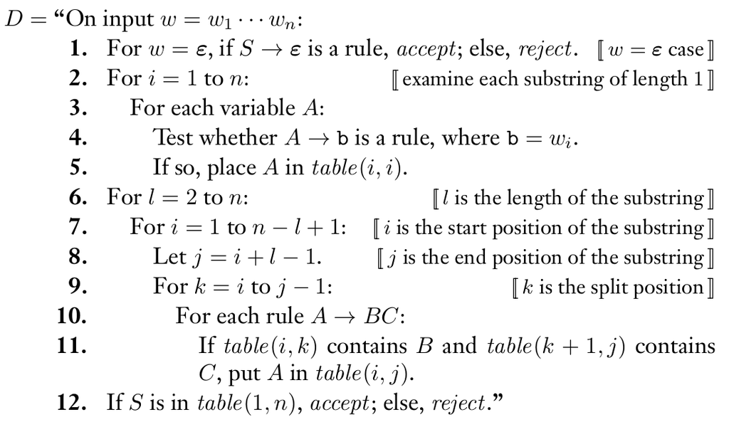

Look at the nested loops to estimate running time.